# Transformación Box-Cox para predecir luminosidad a partir de la masa estelar

Aguirre César, Bartolon Gustavo & Luján Uziel

# Análisis de Masa y Luminosidad Estelar

Este análisis utiliza datos de temperatura efectiva ($T_{\text{eff}}$) para calcular propiedades estelares como masa y luminosidad. Además, se aplica la transformación de Box-Cox para mejorar las relaciones lineales y se realizan predicciones sobre nuevos datos.

## Carga de Librerías y Datos

Se cargan las librerías necesarias y los datos provenientes de un archivo `.ods`. Este conjunto de datos incluye información sobre la temperatura efectiva ($T_{\text{eff}}$) de diferentes estrellas.

```r
library(ggplot2)
library(MASS)
library(readODS)
```

```r
file_path <- "/home/cesar/Documentos/Masas.ods" # Cambiar la ruta acorde a la ubicación en tu computadora
data <- read_ods(file_path, sheet = 1)
head(data)
```

| bestobjid | specobjid | plate | mjd | fiberid | T_eff | Fe_H | Log_g | snr | flag |
| --- | --- | --- | --- | --- | --- | --- | --- | --- | --- |
| 1.237649e+18 | 3.277251e+17 | 291 | 51928 | 321 | 5607.193 | -0.5947440 | 4.224492 | 40.17496 | nnnnn |
| 1.237649e+18 | 3.277397e+17 | 291 | 51928 | 374 | 5551.328 | -0.2771336 | 4.102210 | 35.83231 | nnBnn |
| 1.237671e+18 | 3.277540e+17 | 291 | 51928 | 426 | 5802.190 | -0.7850616 | 4.197660 | 34.46883 | nnnnn |
| 1.237672e+18 | 3.277664e+17 | 291 | 51928 | 471 | 6205.945 | -1.4838500 | 4.105607 | 52.50552 | nnnnn |
| 1.237649e+18 | 3.636662e+17 | 323 | 51615 | 2 | 4235.149 | -1.2312030 | 4.297004 | 30.86933 | nnngn |
| 1.237649e+18 | 3.636671e+17 | 323 | 51615 | 5 | 4177.424 | -1.4968280 | 4.476445 | 30.36025 | nnngn |

## Cálculo de Masa Estelar

La masa estelar se calcula en función de la temperatura efectiva usando una relación proporcional: - Si $T_{\text{eff}} < T_{\odot}$: $M \propto \left(\frac{T_{\text{eff}}}{T_{\odot}}\right)^2$ - Si $T_{\text{eff}} \geq T_{\odot}$: $M \propto \left(\frac{T_{\text{eff}}}{T_{\odot}}\right)^4$

```r
T_sun <- 5778  # Temperatura en Kelvin

# Función para calcular masa estelar
calculate_mass <- function(T_eff) {
  if (T_eff < T_sun) {
    return((T_eff / T_sun)^2)
  } else {
    return((T_eff / T_sun)^4)
  }
}

# Aplicar función a los datos
data$Masa_estelar <- sapply(data$T_eff, calculate_mass)
head(data[c("T_eff", "Masa_estelar")])
```

| T_eff | Masa_estelar |
| --- | --- |
| 5607.193 | 0.9417507 |
| 5551.328 | 0.9230786 |
| 5802.190 | 1.0168517 |
| 6205.945 | 1.3308268 |
| 4235.149 | 0.5372573 |
| 4177.424 | 0.5227115 |

## Cálculo de Luminosidad Estelar

La luminosidad estelar ($L$) se calcula en función de la masa ($M$) y la temperatura efectiva ($T_{\text{eff}}$). La relación utilizada considera que:

1. El radio estelar ($R$) es proporcional a $M^{0.8}$.
2. La luminosidad es proporcional a $R^2 \cdot \left(\frac{T_{\text{eff}}}{T_{\odot}}\right)^4$.

Por lo tanto, la fórmula es:
$$L \propto R^2 \cdot \left(\frac{T_{\text{eff}}}{T_{\odot}}\right)^4,
\quad \text{donde} \quad R \propto M^{0.8}.$$

```r
# Función para calcular luminosidad
calculate_luminosity <- function(mass, T_eff) {
  R <- mass^0.8
  L <- R^2 * (T_eff / T_sun)^4
  return(L)
}

# Aplicar función a los datos
data$Luminosidad <- mapply(calculate_luminosity, data$Masa_estelar, data$T_eff)
head(data[c("T_eff", "Masa_estelar", "Luminosidad")])
```

| T_eff | Masa_estelar | Luminosidad |
| --- | --- | --- |
| 5607.193 | 0.9417507 | 0.80569258 |
| 5551.328 | 0.9230786 | 0.74965135 |
| 5802.190 | 1.0168517 | 1.04440718 |
| 6205.945 | 1.3308268 | 2.10240317 |
| 4235.149 | 0.5372573 | 0.10682092 |
| 4177.424 | 0.5227115 | 0.09677058 |

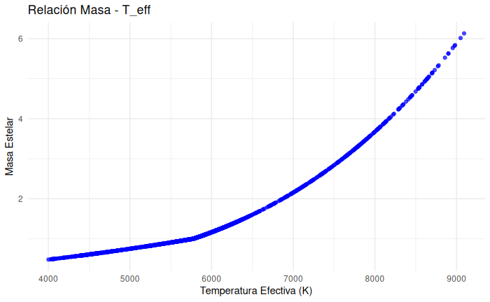

```r
# Relación Masa - T_eff
ggplot(data, aes(x = T_eff, y = Masa_estelar)) +
  geom_point(color = "blue", alpha = 0.7) +
  labs(title = "Relación Masa - T_eff", x = "Temperatura Efectiva (K)", y = "Masa Estelar") +
  theme_minimal()
```

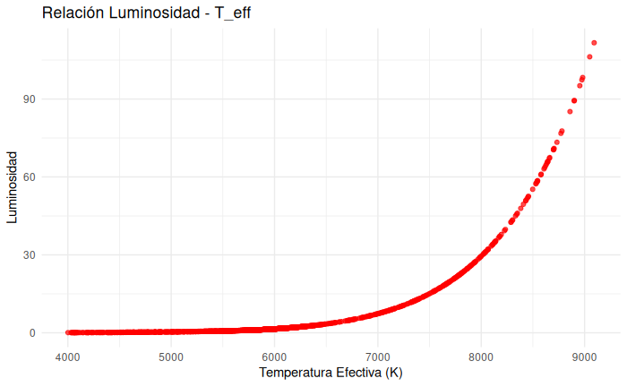

```r
# Relación Luminosidad - T_eff
ggplot(data, aes(x = T_eff, y = Luminosidad)) +
  geom_point(color = "red", alpha = 0.7) +
  labs(title = "Relación Luminosidad - T_eff", x = "Temperatura Efectiva (K)", y = "Luminosidad") +
  theme_minimal()
```

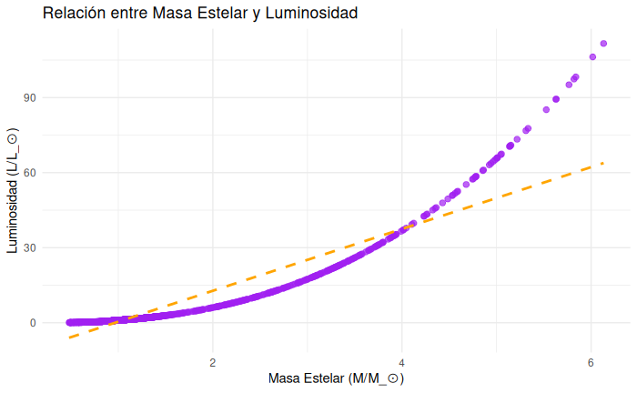

```r
# Relación entre Masa Estelar y Luminosidad
ggplot(data, aes(x = Masa_estelar, y = Luminosidad)) +
  geom_point(color = "purple", alpha = 0.7, size = 2) +
  geom_smooth(method = "lm", color = "orange", linetype = "dashed", se = FALSE) + # Línea de tendencia
  labs(
    title = "Relación entre Masa Estelar y Luminosidad",
    x = "Masa Estelar (M/M_⊙)",
    y = "Luminosidad (L/L_⊙)"
  ) +
  theme_minimal()
```

```r
# M_⊙ := Masa del Sol
# L_⊙ := Luminosidad del Sol
```

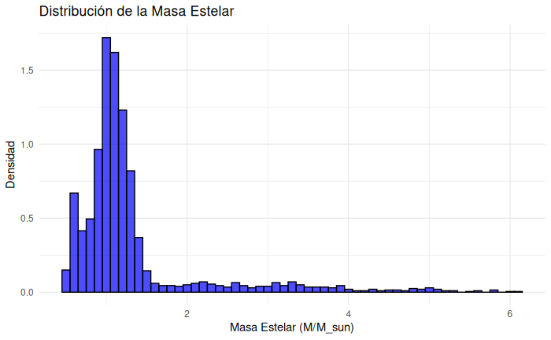

```r
# Histograma y densidad de la masa estelar
ggplot(data, aes(x = Masa_estelar)) +
  geom_histogram(aes(y = ..density..), binwidth = 0.1, fill = "blue", color = "black", alpha = 0.7) +
  labs(
    title = "Distribución de la Masa Estelar",
    x = "Masa Estelar (M/M_sun)",
    y = "Densidad"
  ) +
  theme_minimal()
```

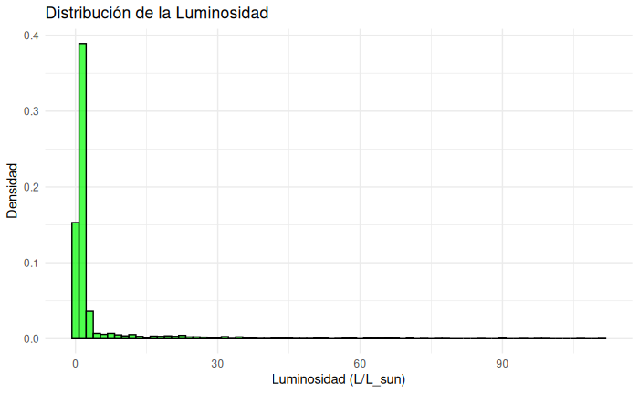

```r
# Histograma y densidad de la luminosidad
ggplot(data, aes(x = Luminosidad)) +
  geom_histogram(aes(y = ..density..), binwidth = 1.5, fill = "green", color = "black", alpha = 0.7)+
  labs(
    title = "Distribución de la Luminosidad",
    x = "Luminosidad (L/L_sun)",
    y = "Densidad"
  ) +
  theme_minimal()
```

## Transformaciones Box-Cox

Se aplica la transformación de Box-Cox para mejorar la linealidad de las relaciones entre variables.

```r
# Función para calcular la verosimilitud logarítmica de Box-Cox
log_likelihood_boxcox <- function(y, lambda) {
  n <- length(y)
  if (lambda == 0) {
    # Caso especial: logaritmo
    y_trans <- log(y)
  } else {
    # Transformación general
    y_trans <- (y^lambda - 1) / lambda
  }
  log_likelihood <- -n / 2 * log(var(y_trans)) + (lambda - 1) * sum(log(y))
  return(log_likelihood)
}

# Encontrar el mejor lambda
find_optimal_lambda <- function(y, lambda_seq) {
  log_likelihoods <- sapply(lambda_seq, log_likelihood_boxcox, y = y)
  optimal_lambda <- lambda_seq[which.max(log_likelihoods)]
  return(list(optimal_lambda = optimal_lambda, log_likelihoods = log_likelihoods))
}

# Aplicar la transformación Box-Cox
apply_boxcox <- function(y, lambda) {
  if (lambda == 0) {
    return(log(y))
  } else {
    return((y^lambda - 1) / lambda)
  }
}

# Secuencia de valores lambda usando método de Grid Search
lambda_seq <- seq(-2, 2, 0.1)

# Aplicar para Masa Estelar
result_masa <- find_optimal_lambda(data$Masa_estelar, lambda_seq)
lambda_masa <- result_masa$optimal_lambda
cat("Lambda óptimo para Masa Estelar:", lambda_masa, "\n")
```

```
Lambda óptimo para Masa Estelar: -0.8
```

```r
data$Masa_estelar_BoxCox <- apply_boxcox(data$Masa_estelar, lambda_masa)

# Aplicar para Luminosidad
result_luminosidad <- find_optimal_lambda(data$Luminosidad, lambda_seq)
lambda_luminosidad <- result_luminosidad$optimal_lambda
cat("Lambda óptimo para Luminosidad:", lambda_luminosidad, "\n")
```

```
Lambda óptimo para Luminosidad: -0.2
```

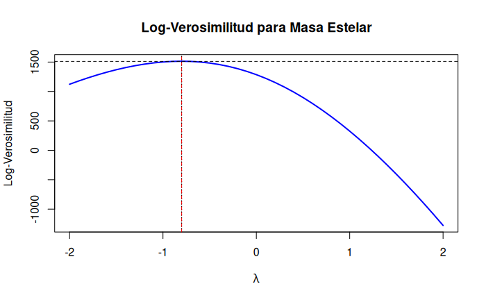

```r
data$Luminosidad_BoxCox <- apply_boxcox(data$Luminosidad, lambda_luminosidad)

# Función general para calcular log-verosimilitud e intervalo de confianza
calculate_ci <- function(log_likelihoods, lambda_seq) {
  max_ll <- max(log_likelihoods)
  cutoff <- max_ll - 0.5 * qchisq(0.95, df = 1)
  ci_indices <- which(log_likelihoods >= cutoff)
  ci_lambda <- range(lambda_seq[ci_indices])
  return(list(cutoff = cutoff, ci_lambda = ci_lambda))
}

# Función para graficar log-verosimilitud
plot_log_likelihood <- function(log_likelihoods, lambda_seq, optimal_lambda, title) {
  ci <- calculate_ci(log_likelihoods, lambda_seq)
  plot(lambda_seq, log_likelihoods, type = "l", col = "blue", lwd = 2,
       main = title, xlab = expression(lambda), ylab = "Log-Verosimilitud")
  abline(h = ci$cutoff, col = "black", lty = 2)
  abline(v = ci$ci_lambda, col = "black", lty = 3)
  abline(v = optimal_lambda, col = "red", lty = 2)
}

# Aplicar y graficar para Masa Estelar
lambda_seq <- seq(-2, 2, 0.1)
log_likelihoods_masa <- result_masa$log_likelihoods
plot_log_likelihood(log_likelihoods_masa, lambda_seq, lambda_masa,
                    title = "Log-Verosimilitud para Masa Estelar")
```

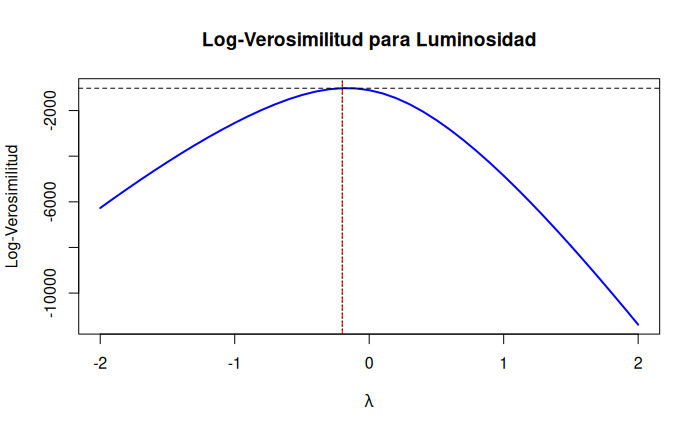

```r
# Aplicar y graficar para Luminosidad
log_likelihoods_luminosidad <- result_luminosidad$log_likelihoods
plot_log_likelihood(log_likelihoods_luminosidad, lambda_seq, lambda_luminosidad,
                    title = "Log-Verosimilitud para Luminosidad")
```

```r
head(data)
```

| bestobjid | specobjid | plate | mjd | fiberid | T_eff | Fe_H | Log_g | snr | flag | Masa_estelar | Luminosidad | Masa_estelar_BoxCox | Luminosidad_BoxCox |
| --- | --- | --- | --- | --- | --- | --- | --- | --- | --- | --- | --- | --- | --- |
| 1.237649e+18 | 3.277251e+17 | 291 | 51928 | 321 | 5607.193 | -0.5947440 | 4.224492 | 40.17496 | nnnnn | 0.9417507 | 0.80569258 | -0.06147877 | -0.2207889 |
| 1.237649e+18 | 3.277397e+17 | 291 | 51928 | 374 | 5551.328 | -0.2771336 | 4.102210 | 35.83231 | nnBnn | 0.9230786 | 0.74965135 | -0.08265905 | -0.2966117 |
| 1.237671e+18 | 3.277540e+17 | 291 | 51928 | 426 | 5802.190 | -0.7850616 | 4.197660 | 34.46883 | nnnnn | 1.0168517 | 1.04440718 | 0.01660011 | 0.0432612 |
| 1.237672e+18 | 3.277664e+17 | 291 | 51928 | 471 | 6205.945 | -1.4838500 | 4.105607 | 52.50552 | nnnnn | 1.3308268 | 2.10240317 | 0.25548169 | 0.6905008 |
| 1.237649e+18 | 3.636662e+17 | 323 | 51615 | 2 | 4235.149 | -1.2312030 | 4.297004 | 30.86933 | nnngn | 0.5372573 | 0.10682092 | -0.80477448 | -2.8205760 |
| 1.237649e+18 | 3.636671e+17 | 323 | 51615 | 5 | 4177.424 | -1.4968280 | 4.476445 | 30.36025 | nnngn | 0.5227115 | 0.09677058 | -0.85039212 | -2.9766647 |

```r
NA
```

## Comparación de Distribuciones

Se comparan las distribuciones originales y transformadas de Masa y Luminosidad.

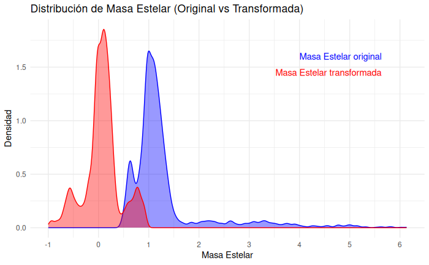

```r
# Comparar distribuciones de Masa Estelar antes y después de Box-Cox
ggplot(data) +
  geom_density(aes(x = Masa_estelar), color = "blue", fill = "blue", alpha = 0.4) +
  geom_density(aes(x = Masa_estelar_BoxCox), color = "red", fill = "red", alpha = 0.4) +
  labs(
    title = "Distribución de Masa Estelar (Original vs Transformada)",
    x = "Masa Estelar",
    y = "Densidad"
  ) +
  scale_x_continuous(
    limits = c(min(c(data$Masa_estelar, data$Masa_estelar_BoxCox)),
               max(c(data$Masa_estelar, data$Masa_estelar_BoxCox))),
    breaks = scales::pretty_breaks(n = 10)
  ) +
  theme_minimal() +
  annotate("text", x = max(c(data$Masa_estelar, data$Masa_estelar_BoxCox)) - 0.5,
           y = max(density(data$Masa_estelar)$y) - 0.05, label = "Masa Estelar original", color = "blue", hjust = 1) +
  annotate("text", x = max(c(data$Masa_estelar, data$Masa_estelar_BoxCox)) - 0.5,
           y = max(density(data$Masa_estelar)$y) - 0.20, label = "Masa Estelar transformada", color = "red", hjust = 1)
```

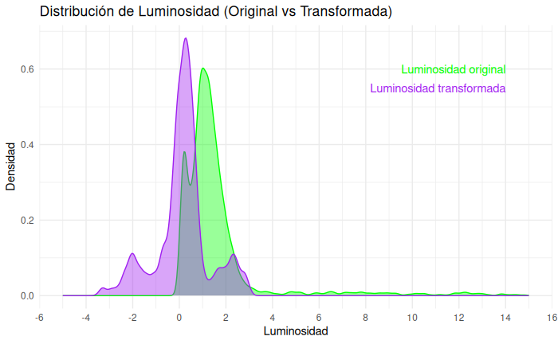

```r
# Comparar distribuciones de Luminosidad antes y después de Box-Cox
ggplot(data) +
  geom_density(aes(x = Luminosidad), color = "green", fill = "green", alpha = 0.4) +
  geom_density(aes(x = Luminosidad_BoxCox), color = "purple", fill = "purple", alpha = 0.4) +
  labs(
    title = "Distribución de Luminosidad (Original vs Transformada)",
    x = "Luminosidad",
    y = "Densidad"
  ) +
  scale_x_continuous(
    limits = c(-5, 15),
    breaks = scales::pretty_breaks(n = 10)
  ) +
  theme_minimal() +
  annotate("text", x = 14, y = 0.6, label = "Luminosidad original", color = "green", hjust = 1) +
  annotate("text", x = 14, y = 0.55, label = "Luminosidad transformada", color = "purple", hjust = 1)
```

## Comparación de Modelos Lineales

Se ajustan modelos de regresión lineal antes y después de la transformación para evaluar mejoras.

```r
# Regresión antes de Box-Cox
modelo_original <- lm(Luminosidad ~ Masa_estelar, data = data)
summary(modelo_original)
```

```
Call:
lm(formula = Luminosidad ~ Masa_estelar, data = data)

Residuals:
   Min     1Q Median     3Q    Max
-8.209 -1.677 -0.118  1.301 47.790

Coefficients:
             Estimate Std. Error t value Pr(>|t|)
(Intercept)  -11.9399     0.1756  -67.99   <2e-16 ***
Masa_estelar  12.3589     0.1122  110.17   <2e-16 ***
---
Signif. codes:  0 ‘***’ 0.001 ‘**’ 0.01 ‘*’ 0.05 ‘.’ 0.1 ‘ ’ 1

Residual standard error: 4.262 on 1998 degrees of freedom
Multiple R-squared:  0.8587,    Adjusted R-squared:  0.8586
F-statistic: 1.214e+04 on 1 and 1998 DF,  p-value: < 2.2e-16
```

```r
# Regresión después de Box-Cox
modelo_transformado <- lm(Luminosidad_BoxCox ~ Masa_estelar_BoxCox, data = data)
summary(modelo_transformado)
```

```
Call:
lm(formula = Luminosidad_BoxCox ~ Masa_estelar_BoxCox, data = data)

Residuals:
      Min        1Q    Median        3Q       Max
-0.183767 -0.048295  0.008508  0.055344  0.091020

Coefficients:
                     Estimate Std. Error t value Pr(>|t|)
(Intercept)         -0.091095   0.001444   -63.1   <2e-16 ***
Masa_estelar_BoxCox  3.211409   0.003932   816.6   <2e-16 ***
---
Signif. codes:  0 ‘***’ 0.001 ‘**’ 0.01 ‘*’ 0.05 ‘.’ 0.1 ‘ ’ 1

Residual standard error: 0.06323 on 1998 degrees of freedom
Multiple R-squared:  0.997, Adjusted R-squared:  0.997
F-statistic: 6.669e+05 on 1 and 1998 DF,  p-value: < 2.2e-16
```

## Resultados Finales

Se evalúan las predicciones realizadas a partir de los modelos ajustados.

```r
plot_original <- ggplot(data, aes(x = Masa_estelar, y = Luminosidad)) +
  geom_point(alpha = 0.5, color = "blue") +
  geom_smooth(method = "lm", color = "red", se = TRUE) +
  labs(
    title = "Regresión Lineal Antes de la Transformación",
    x = "Masa Estelar (Original)",
    y = "Luminosidad (Original)"
  ) +
  theme_minimal()

plot_transformado <- ggplot(data, aes(x = Masa_estelar_BoxCox, y = Luminosidad_BoxCox)) +
  geom_point(alpha = 0.5, color = "green") +
  geom_smooth(method = "lm", color = "red", se = TRUE) +
  labs(
    title = "Regresión Lineal Después de la Transformación Box-Cox",
    x = "Masa Estelar (Box-Cox)",
    y = "Luminosidad (Box-Cox)"
  ) +
  theme_minimal()

summary_original <- summary(modelo_original)
cat("Modelo Antes de Box-Cox\n")
```

```
Modelo Antes de Box-Cox
```

```r
cat("R^2:", summary_original$r.squared, "\n")
```

```
R^2: 0.8586526
```

```r
cat("Error Estándar Residual (RMSE):", sqrt(mean(residuals(modelo_original)^2)), "\n\n")
```

```
Error Estándar Residual (RMSE): 4.259427
```

```r
summary_transformado <- summary(modelo_transformado)
cat("Modelo Después de Box-Cox\n")
```

```
Modelo Después de Box-Cox
```

```r
cat("R^2:", summary_transformado$r.squared, "\n")
```

```
R^2: 0.997013
```

```r
cat("Error Estándar Residual (RMSE):", sqrt(mean(residuals(modelo_transformado)^2)), "\n")
```

```
Error Estándar Residual (RMSE): 0.06319512
```

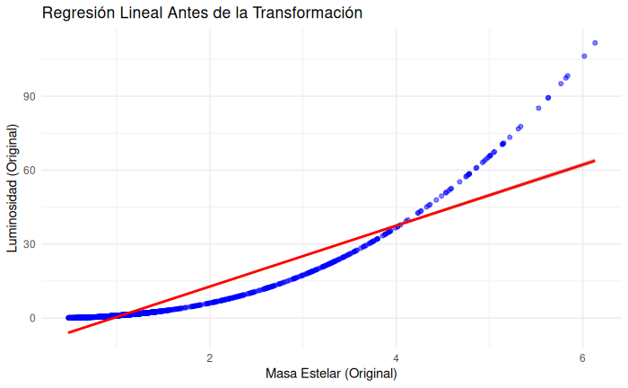

```r
print(plot_original)
```

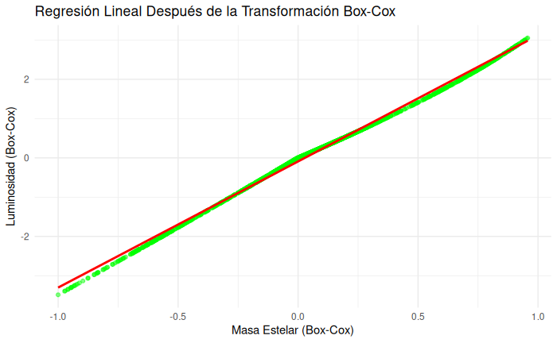

```r
print(plot_transformado)
```

## Validación con Nuevos Datos

En esta sección, se utilizan datos nuevos para evaluar el modelo desarrollado. El objetivo es predecir la luminosidad estelar en función de la masa estelar y validar las predicciones mediante el cálculo de residuos, $R^2$, y MSE.

### Cargar Nuevos Datos

Se cargan los nuevos datos desde un archivo `.ods`, los cuales contienen la temperatura efectiva ($T_{\text{eff}}$) para predicción.

```r
file_path <- "/home/cesar/Documentos/Masas-a-predecir.ods" # Cambiar la ruta acorde a la ubicación en tu computadora
nuevos_datos <- read_ods(file_path, sheet = 1)
head(nuevos_datos)
```

| bestobjid | specobjid | plate | mjd | fiberid | T_eff | Fe_H | Log_g | snr | flag |
| --- | --- | --- | --- | --- | --- | --- | --- | --- | --- |
| 1.237674e+18 | 6.384628e+17 | 567 | 52252 | 282 | 4290.597 | -0.3185627 | 4.021944 | 36.81591 | nnnnn |
| 1.237655e+18 | 9.503508e+17 | 844 | 52378 | 332 | 4428.212 | -1.0032120 | 4.449655 | 34.34809 | nnngn |
| 1.237655e+18 | 9.503921e+17 | 844 | 52378 | 482 | 4450.021 | -0.2830430 | 4.061141 | 36.45467 | nnnnn |
| 1.237655e+18 | 9.515540e+17 | 845 | 52381 | 613 | 4433.001 | -0.4737204 | 4.312070 | 34.37865 | nnnnn |
| 1.237655e+18 | 9.547739e+17 | 848 | 52669 | 39 | 4444.466 | -0.5986178 | 4.425775 | 41.16568 | nnnnn |
| 1.237655e+18 | 9.571024e+17 | 850 | 52338 | 318 | 4373.618 | -1.1510580 | 4.416594 | 48.24619 | nnngn |

### Aplicar Transformaciones Box-Cox

```r
file_path <- "/home/cesar/Documentos/Masas-a-predecir.ods"
nuevos_datos <- read_ods(file_path, sheet = 1)

if (!"T_eff" %in% colnames(nuevos_datos)) {
  stop("La columna 'T_eff' no está presente en los datos.")
}
nuevos_datos$T_eff <- as.numeric(nuevos_datos$T_eff)

nuevos_datos$Masa_estelar <- sapply(nuevos_datos$T_eff, calculate_mass)
nuevos_datos$Luminosidad <- mapply(calculate_luminosity, nuevos_datos$Masa_estelar, nuevos_datos$T_eff)

lambda_masa <- -0.7878788
if (lambda_masa == 0) {
  nuevos_datos$Masa_estelar_BoxCox <- log(nuevos_datos$Masa_estelar)
} else {
  nuevos_datos$Masa_estelar_BoxCox <- (nuevos_datos$Masa_estelar^lambda_masa - 1) / lambda_masa
}

lambda_luminosidad <- -0.1818182
nuevos_datos$Luminosidad_Pred_Transformada <- predict(modelo_transformado, newdata = nuevos_datos)

nuevos_datos$Luminosidad_Pred <- inverse_boxcox(nuevos_datos$Luminosidad_Pred_Transformada, lambda_luminosidad)

head(nuevos_datos[c("T_eff", "Masa_estelar", "Masa_estelar_BoxCox", "Luminosidad", "Luminosidad_Pred")])
```

| T_eff | Masa_estelar | Masa_estelar_BoxCox | Luminosidad | Luminosidad_Pred |
| --- | --- | --- | --- | --- |
| 4290.597 | 0.5514173 | -0.7594921 | 0.1173085 | 0.1247438 |
| 4428.212 | 0.5873564 | -0.6610390 | 0.1472469 | 0.1555853 |
| 4450.021 | 0.5931562 | -0.6461534 | 0.1525487 | 0.1609967 |
| 4433.001 | 0.5886275 | -0.6577541 | 0.1483973 | 0.1567607 |
| 4444.466 | 0.5916762 | -0.6499271 | 0.1511829 | 0.1596041 |
| 4373.618 | 0.5729631 | -0.6991427 | 0.1346653 | 0.1426840 |

### Comparación de Predicciones

Se comparan las predicciones realizadas por el modelo con los valores calculados para validar el desempeño.

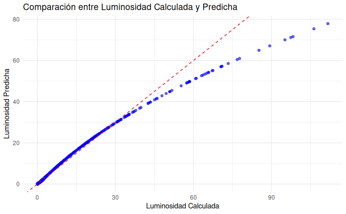

```r
ggplot(nuevos_datos, aes(x = Luminosidad, y = Luminosidad_Pred)) +
  geom_point(color = "blue", alpha = 0.6) +
  geom_abline(slope = 1, intercept = 0, color = "red", linetype = "dashed") +
  labs(
    title = "Comparación entre Luminosidad Calculada y Predicha",
    x = "Luminosidad Calculada",
    y = "Luminosidad Predicha"
  ) +
  theme_minimal()
```

### Métricas de Validación

Se calculan $R^2$ y el Error Cuadrático Medio (MSE) para evaluar el desempeño del modelo.

```r
nuevos_datos$Luminosidad_Real <- nuevos_datos$Luminosidad
r_squared <- cor(nuevos_datos$Luminosidad_Real, nuevos_datos$Luminosidad_Pred)^2
mse <- mean((nuevos_datos$Luminosidad_Real - nuevos_datos$Luminosidad_Pred)^2)

cat("R²:", r_squared, "\n")
```

```
R²: 0.9815023
```

```r
cat("MSE:", mse, "\n")
```

```
MSE: 4.294422
```

### Análisis de Residuos

Se analiza el comportamiento de los residuos para identificar posibles sesgos en el modelo.

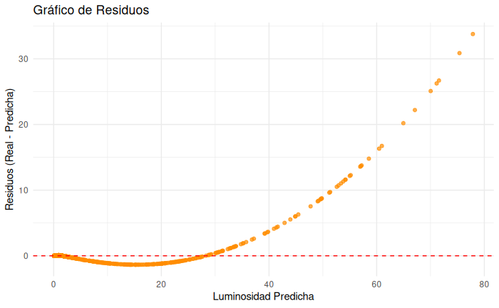

```r
nuevos_datos$residuos <- nuevos_datos$Luminosidad_Real - nuevos_datos$Luminosidad_Pred

ggplot(nuevos_datos, aes(x = Luminosidad_Pred, y = residuos)) +
  geom_point(color = "darkorange", alpha = 0.7) +
  geom_hline(yintercept = 0, color = "red", linetype = "dashed") +
  labs(
    title = "Gráfico de Residuos",
    x = "Luminosidad Predicha",
    y = "Residuos (Real - Predicha)"
  ) +
  theme_minimal()
```